# Data Science Project - A Review of the Relationship Between Personal Factors and Measured Blood Pressure

Memes and Music: Rich Gude Siwei Yang Junhe Zhang Krystal Payton

March 11, 2020

# Executive Summary:

# Purpose:

To analyze examination and survey data from the National Center of Health Statistics taken from the National Health and Nutrition Examination Surveys from 10,000 interviewees from 2005 and 2006 and identify any link or lackthereof between measured blood pressure data and the ethnicity, gender, age, household income, or veteran status of adult (ages 18 and older) individuals.

# Data Background:

The National Center for Health Statistics (NCHS) conducts an annual series of personal interviews and examinations of 5000 Americans from 15 counties across the United States for the purpose of assessing health and nutrional status of adults and children in the United States. This series of interviews is known as the National Health and Nutrition Examination Surveys (NHANES).

# Study Design

The NCHS conducts in-home interviews of roughly 7,000 individuals of all ages each year. Of these 7,000, roughly 5,000 complete health examination surveys. The target population for interviewees is the non-linstitualized, civilian United States population. The 2005 and 2006 NHANES include an over-samping of teenage adoloescents (ages 12 to 19), elderly individuals (ages 60 or greater), African Americans, and Mexican Americans. Ethnic, gender, age, houshold income, and veteran status data are solicited during the interview portion while blood pressure readings are taken during the examination portion of the NHANES.

Interviews are predominantly conducted in-person at the interviewee’s domicile and are composed of screener, sample person, and family interviews. Interviewees are mailed information regarding the study prior to interveiwer arrival at the domicile and, at the time of the interview, are provided and asked to sign consent forms agreeing to particiapte in the interviews and medical examinations. Blood pressure reading are generally taken at mobile examination centers or, if the participant is unable to make it to the center, within their homes.

# A Discussion of the Data

As stated in the purpose, this study will investigate the relationship, or lack thereof, between the blood pressure and the ethnicity, gender, age, houshold income, or veteran status of an individual. The blood pressure of an individual is a based on a complex series of interactions between many factors including genetics, personal exercise and diet, and access to advanced healthcare. From the NHANES studies, at least some of these factors can be quantified and, accordingly, allow for appropriately quantitative and qualitative testing to identify a prospective magnitude to which these factors may affect blood pressure: ethnicity, gender, and age provide qualitative measures for genetic factors on blood pressure, veteran status provides a qualitative measure for personal exercise [THIS MAY BE A BIG ASSUMPTION AND WE MAY WANT TO DISCUSS FURTHER], and household income provides a quantitative measure for access to advanced healthcare.

The population from which this data is derived is that of 10,000 American individuals from 30 different United States counties. For that reason, the conclusions of this study should only be applied to American individuals as there may be some bias within the data with respect to the American health system and general culture. For instance:

- If household income or veteran status can be considered metrics of access to advanced healthcare, any trend in these two variables with respect to blood pressure may be diminished or exacerbated in comparison to individuals from countries with established publicly-funded healthcare systems (e.g., low-income households may have more access to advanced healthcare in publicly-funded healthcare systems versus those households in the American privately-funded healthcare system).
- There may be general genetic differences in enthnicities in American populations versus similar ethnic populations in other countries, so any trends between the enthincities discussed within this report may not be representatives of said ethnicities outside of the United States.

In addition, as there is limited discussion in the data report regarding where the 30 counties are located within the United States in order to ensure confidentiality of participants, there may be some regional bias within the United States from the data; however, this is difficult to quantify without additional information.

# Data Preprocessing

As part of the survey and examination, the 2005 and 2006 NHANES solicited over 69 variables from the participants (not counting an unique identification number for each participant), including pulse, four reading of the diastolic and systolic pressures each, education level, marital status, and many others. For the purposes of this study, only 18 variables are of particular interest; they are as such:

#### Participant Variables of Interest

**1. Participant Sequence Number**

**2 - 5. Did Participant have food/alcohol/coffee/cigarettes in the 30 minutes prior to the Examination?**

**6 - 9. Four Individual Measures of the Participant Diastolic Blood Pressure (in mmHg)**

**10 - 13. Four Individual Measures of the Participant Systolic Blood Pressure (in mmHg)**

**14. Participant Ethnicity, documented as: Mexican American, Other Hispanic, Non-Hispanic White, Non-Hispanic Black, or Other Race**

**15. Participant Gender, documented as: Male or Female**

**16. Participant Age, documented as: 18 - 85 - particpants 85 and older are topcoded at 85**

**17. Participant Veteran Status, documented as “Did Participant ever serve in the Armed Forces of the United States?”: Yes or No**

**18. Annual Household Income of Participant, documented as ranges of US dollars as such: $0 to $9999, $10000 to $19999, $20000 to $34999, $35000 to $54999, $55000 to $74999, or over $75000** [WE WILL IGNORE THE OTHER CATEGORIES FOR ALL VARIABLES THAT ARE NOT LISTED HERE SUCH AS UNDER $20000 FOR HOUSEHOLD INCOME]

During the examination, four measures of both the systolic and diastolic pressures were taken for each participant. In some cases, less than four measurements were taken. In order to standardize the measured systolic and diastolic pressure measurements, two new columns for the average systolic and diastolic pressures across all of the measurements with relevant measurements, “SystolAvg” and “DiastolAvg”, respectively, were created. All participants with missing data or measured blood pressures of nill (0) for either pressure (clearly indicating an erroronous measurement) were dropped from this study’s consideration.

**[I AM STILL NOT SURE IF THE RIGHT CALL IS TO REMOVE ALL ROWS THAT HAVE MISSING OR INCONEVNIENT DATA IN ANY VARIABLE COLUMN OR HAVE THE 5 SEPARATE DATA SUBSETS… WE MAY NEED TO DISCUSS WITH THE PROFESSOR]**

```r
# This code package preprocesses out all of the columns that are not necessary from the Blood Pressure data as well as all of the rows for participants that do not satisfy the "adult" criteria (anyone with an age < 17 years)

# First subset is to narrow rows by age and select relevant columns
dataSubset <- subset(dataBP, RIDAGEYR > 17, select = c('SEQN', 'BPQ150A', 'BPQ150B', 'BPQ150C', 'BPQ150D', 'BPXSY1', 'BPXSY2', 'BPXSY3', 'BPXSY4', 'BPXDI1', 'BPXDI2', 'BPXDI3', 'BPXDI4', 'RIAGENDR', 'RIDAGEYR', 'RIDRETH1', 'DMQMILIT', 'INDHHINC'))

# The function below shows that all columns are either factors or intergers and all are appropriate to the data
# sapply(dataSubset, class)

# Second Subset is to remove all rows with 'Yes' responses from stimulant/depressant columns (missing columns are treated as 'Yes')

dataSubset <- subset(dataSubset, BPQ150A != 'Yes' &  BPQ150B != 'Yes' & BPQ150C != 'Yes' & BPQ150D != 'Yes')

# Using the summary function, we see that there are many missing values in the systolic and diastolic pressure columns (some have only one or two readings vice 4 like others).  There are tests we could have done if we had four sample pressures for every applicant (such as testing if all of the pressures were the same, but instead we're going to just average all of the columns that have any measurements and use those two averages for all further evaluations.
# Create two new columns that average the values from all of the pressure readings for systolic and diastolic pressures (NAs are not evaluated)

dataSubset$SystolAvg <- rowMeans(dataSubset[c('BPXSY1','BPXSY2','BPXSY3','BPXSY4')], na.rm=TRUE)
dataSubset$DiastolAvg <- rowMeans(dataSubset[c('BPXDI1','BPXDI2','BPXDI3','BPXDI4')], na.rm=TRUE)

# Drop all rows that are 0 or NA in the Average Systolic and Diastolic columns (these are clearly inappropriately marked or missing data that we cannot use), and then drop all rows that we don't need (the original stimulant/depressant marker questions and the four readings for systolic and diastolic pressures).  The column dropping is for general tidiness.

dataSubset <- subset(dataSubset, SystolAvg != 0 &  DiastolAvg != 0, select = c('SEQN', 'SystolAvg', 'DiastolAvg', 'RIAGENDR', 'RIDAGEYR', 'RIDRETH1', 'DMQMILIT', 'INDHHINC'))
summary(dataSubset)
```

```
##       SEQN         SystolAvg     DiastolAvg      RIAGENDR       RIDAGEYR
##  Min.   :31131   Min.   : 73   Min.   : 11.3   Male  :1704   Min.   :18
##  1st Qu.:33842   1st Qu.:110   1st Qu.: 60.7   Female:1753   1st Qu.:28
##  Median :36374   Median :120   Median : 68.7                 Median :44
##  Mean   :36377   Mean   :123   Mean   : 68.6                 Mean   :46
##  3rd Qu.:38967   3rd Qu.:133   3rd Qu.: 76.0                 3rd Qu.:63
##  Max.   :41473   Max.   :270   Max.   :124.0                 Max.   :85
##
##                                 RIDRETH1          DMQMILIT
##  Mexican American                   : 764   Yes       : 458
##  Other Hispanic                     : 111   No        :2998
##  Non-Hispanic White                 :1632   Refused   :   1
##  Non-Hispanic Black                 : 823   Don't know:   0
##  Other Race - Including Multi-Racial: 127
##
##
##                INDHHINC
##  $75,000 and Over  : 707
##  $25,000 to $34,999: 439
##  $35,000 to $44,999: 331
##  $45,000 to $54,999: 324
##  $10,000 to $14,999: 265
##  (Other)           :1353
##  NA's              :  38
```

# Variable Anaylsis and Approach

The purpose of this study is to identify any link or lackthereof between the blood pressure and one of five factors, ethnicity, age, veteran status, gender, and annual household income, based on the survey and examination data from random group of American individuals. Each variable and their associated effect will be examined in the following five sections. Each section will review the distribution of the data within each subcategory of the variable (e.g., male versus female in gender or the five surveyed ethnicities in ethnicity). In order to determine whether blood pressure is dependent or independent of each variable, an Anaylsis of Variance (ANOVA) test for variables with more than two categories or a T-Test for bi-modal variables, such as gender, will be used to identify if there is any difference in the average blood pressure value between the categories. If there is no statistical difference in the average blood pressure values across the categories of a variable, that variable will be considered to not affect blood pressure.

Additional analysis of the governing assumptions for the ANOVA or T-Tests will be presented in each section as appropriate based on the distribution of the data amongst each categorical group.

# The Effect of Ethnicity on Blood Pressure (presented by Rich Gude)

For the sake of this study, the ethnicity of the participant is a qualitative, categorical variable. Participants were asked to provide one of five ethnicities, and the 2005 and 2006 NHANES included an oversampling of Mexican and African Americans. The results of the ethnic information provided by participants in the 2005 and 2006 NHANES studies are provided in the bar graph below:

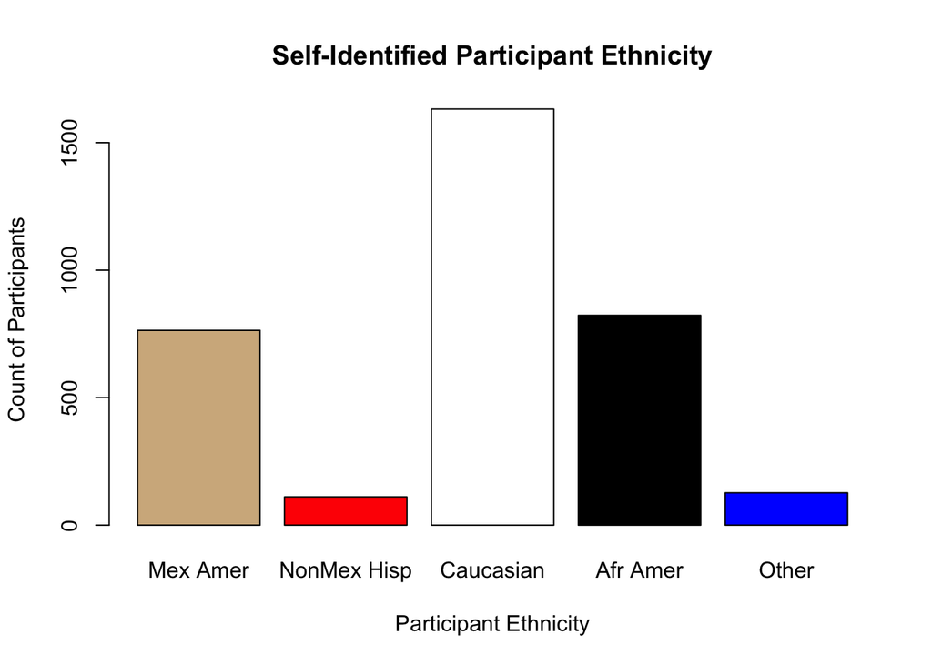

```r
# Create a dummy table to plug into the barplot function.  Define all axises titles and the color palette (coded to ethnicity)
ethnic_Count <- table(dataSubset$RIDRETH1)
barPlot_Ethnicity <- barplot(ethnic_Count,
                             main="Self-Identified Participant Ethnicity",
                             xlab="Participant Ethnicity",
                             ylab='Count of Participants',
                             names.arg= c('Mex Amer', 'NonMex Hisp', 'Caucasian', 'Afr Amer', 'Other'),
                             col= c('tan', 'red', 'white', 'black', 'blue'))
```

This study will use the ethnic and blood pressure data from 3457 total participants who passed the data preprocessing steps described above (i.e., those that are of age and contained adequeate blood pressure data). Of those: 764 or 22.1% were Mexican American, 111 or 3.211% were Non-Mexican Hispanic American, 1632 or 47.209% were Caucasian American, 823 or 23.807% were African American, and 127 or 3.674% were another ethnicity or multiethnic.

## Discussion of the Normality and other Assumptions of the ANOVA Test for Blood Pressure Data between Ethnic Groups

The Analysis of Variance (ANOVA) Test can be used to identify whether all of the ethnic groups accounted within the dataset have the same systolic blood pressures; however, the ANOVA test assumes three facets of the data: 1. The data for each group is normally distributed. 2. The variance in the data within each group is equivalent to other groups 3. The error within the data is independent of the magnitude of the value

The following tests were performed in order to verify the assumptions of the ANOVA test: The Shapiro-Wilk Test will be used to determine the whether the data is normally distributed amongst each ethnicity and blood pressure type, the Bartlett test of homogeneity of variances will be used to test whether the variance within each group is equivalent, and a plot of the residuals from the ANOVA test object will identify the extent of the error within the data and whether it changes with blood pressure values. For the Shapiro-Wilk test, the null hypothesis is the data is normally distributed with respect to the blood pressure; for a Shapiro-Wilk probability value less than 0.05 (based on a 95% confidence interval), the data will not be considered normally-distributed between for the given ethnic group and blood pressure type. For the Bartlett test, the null hypothesis is the variance in data between the groups is equivalent; for a Bartlett probability less than 0.05 (based on a 95% confidence interval), the variance will not be considered equivalent between all five ethnic groups.

The histogram plot of the average systolic and diastolic blood pressures from each ethnic group are presented below:

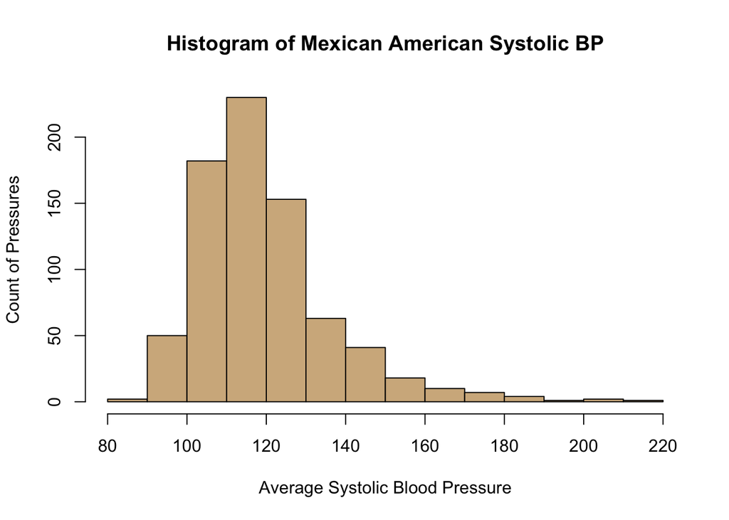

```r
# Develop a dummy dataframe for Mexican American histograms
dumMexican <- subset(dataSubset, RIDRETH1 == 'Mexican American')
hist_MexSyst <- hist(dumMexican$SystolAvg,
                     main="Histogram of Mexican American Systolic BP",
                     xlab="Average Systolic Blood Pressure",
                     ylab='Count of Pressures',
                     col='tan')
```

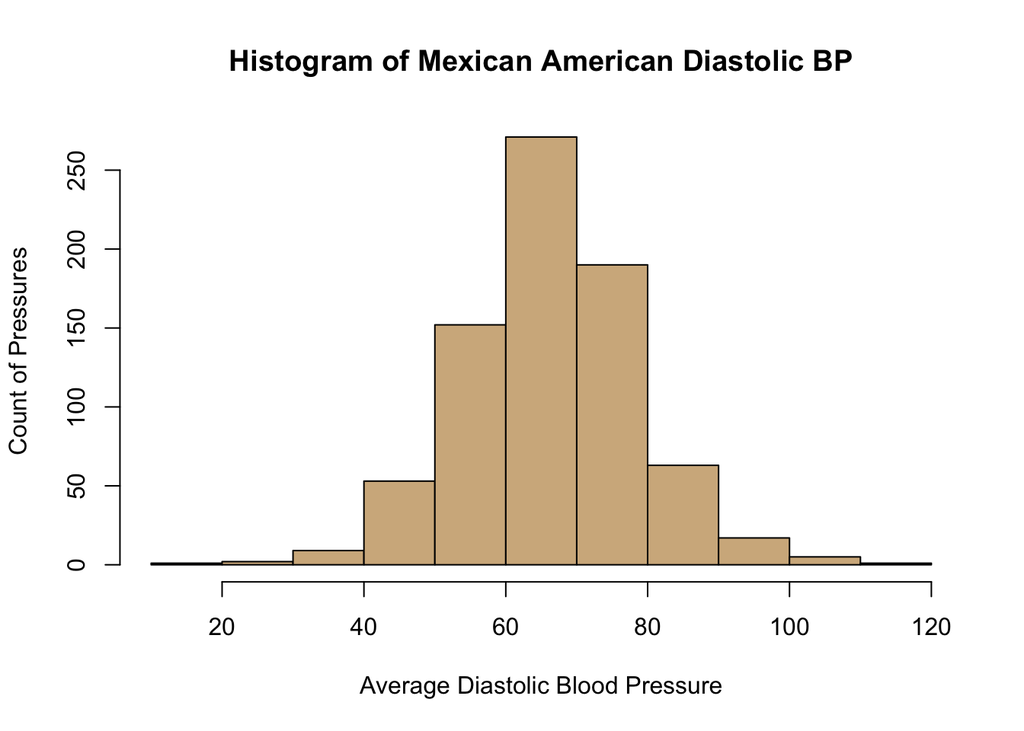

```r
hist_MexDias <- hist(dumMexican$DiastolAvg,
                     main="Histogram of Mexican American Diastolic BP",
                     xlab="Average Diastolic Blood Pressure",
                     ylab='Count of Pressures',
                     col='tan')
```

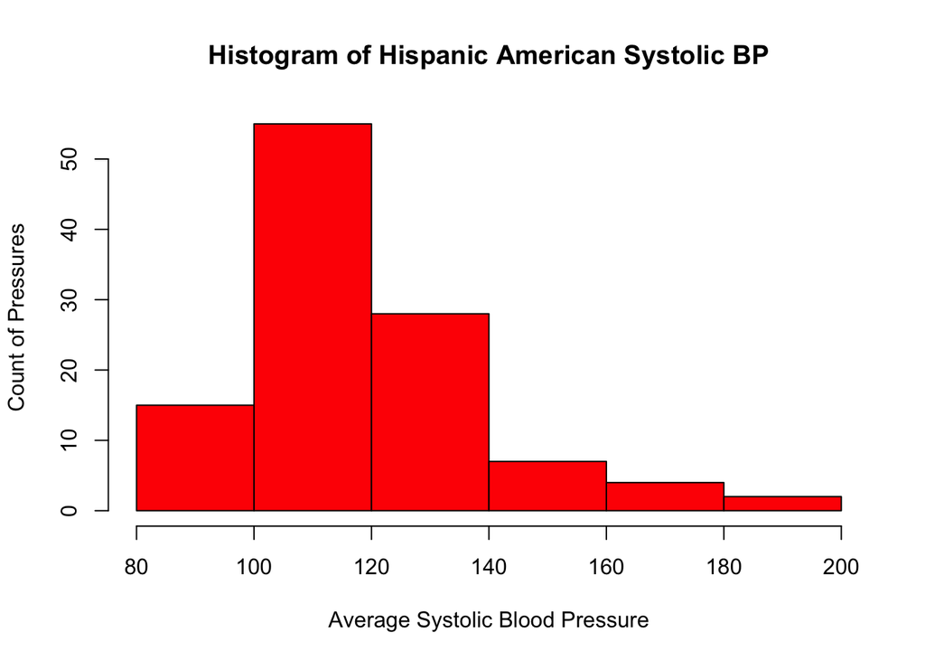

```r
# Develop a dummy dataframe for Hispanic American histograms
dumHispanic <- subset(dataSubset, RIDRETH1 == 'Other Hispanic')
hist_HisSyst <- hist(dumHispanic$SystolAvg,
                     main="Histogram of Hispanic American Systolic BP",
                     xlab="Average Systolic Blood Pressure",
                     ylab='Count of Pressures',
                     col='red')
```

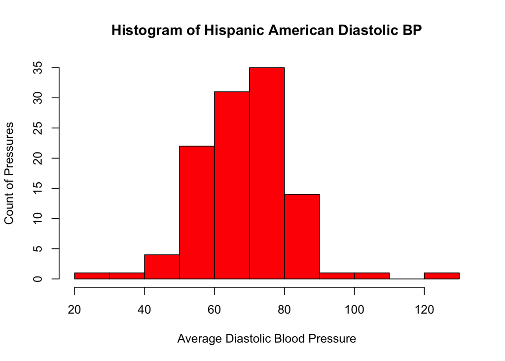

```r
hist_HisDias <- hist(dumHispanic$DiastolAvg,
                     main="Histogram of Hispanic American Diastolic BP",
                     xlab="Average Diastolic Blood Pressure",
                     ylab='Count of Pressures',
                     col='red')
```

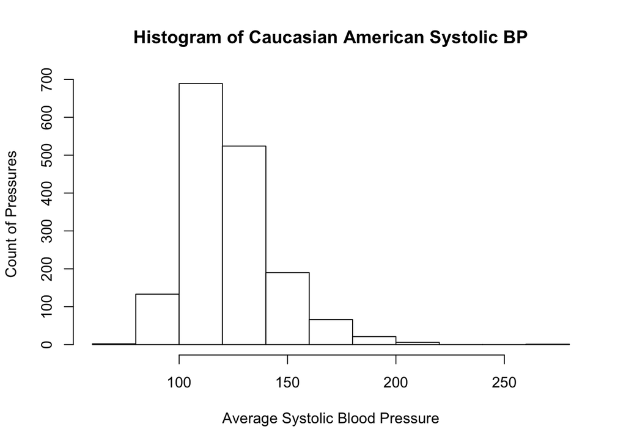

```r
# Develop a dummy dataframe for Caucasian American histograms
dumCaucasian <- subset(dataSubset, RIDRETH1 == 'Non-Hispanic White')
hist_CauSyst <- hist(dumCaucasian$SystolAvg,
                     main="Histogram of Caucasian American Systolic BP",
                     xlab="Average Systolic Blood Pressure",
                     ylab='Count of Pressures',
                     col='white')
```

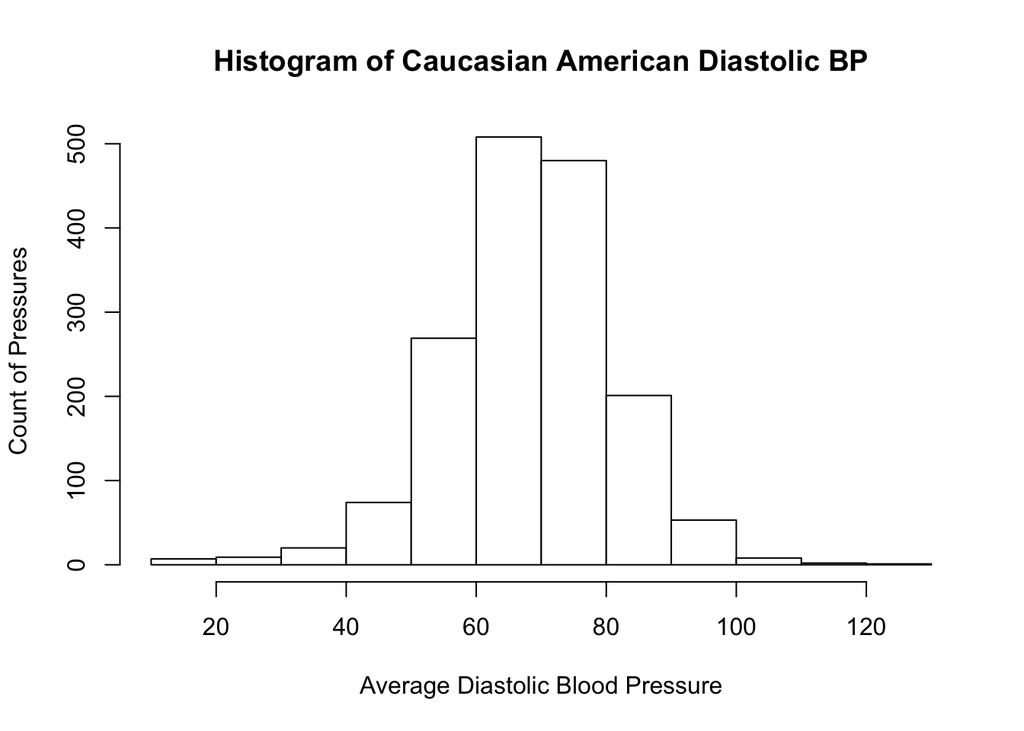

```r
hist_CauDias <- hist(dumCaucasian$DiastolAvg,
                     main="Histogram of Caucasian American Diastolic BP",
                     xlab="Average Diastolic Blood Pressure",
                     ylab='Count of Pressures',
                     col='white')
```

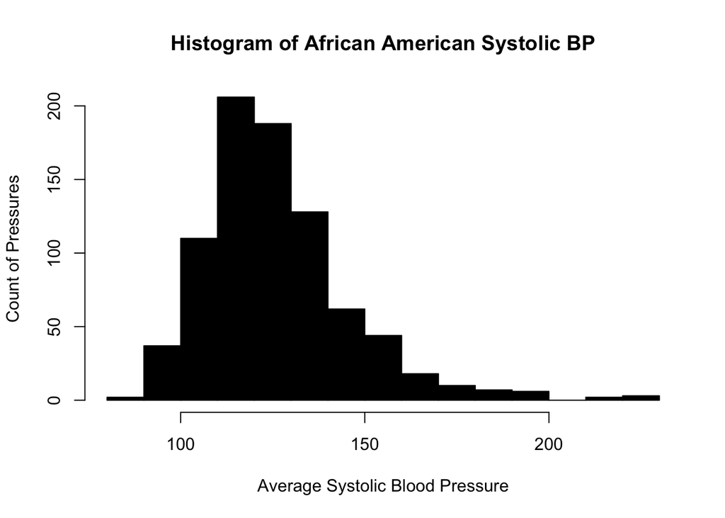

```r
# Develop a dummy dataframe for African American histograms
dumAfrican <- subset(dataSubset, RIDRETH1 == 'Non-Hispanic Black')
hist_AfrSyst <- hist(dumAfrican$SystolAvg,
                     main="Histogram of African American Systolic BP",
                     xlab="Average Systolic Blood Pressure",
                     ylab='Count of Pressures',
                     col='black')
```

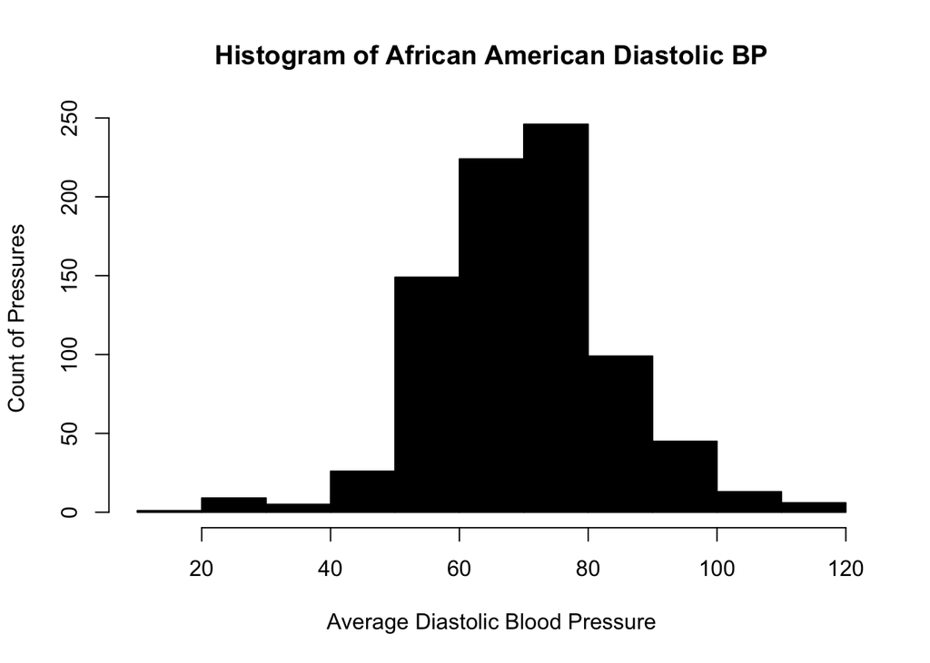

```r
hist_AfrDias <- hist(dumAfrican$DiastolAvg,
                     main="Histogram of African American Diastolic BP",
                     xlab="Average Diastolic Blood Pressure",
                     ylab='Count of Pressures',
                     col='black')
```

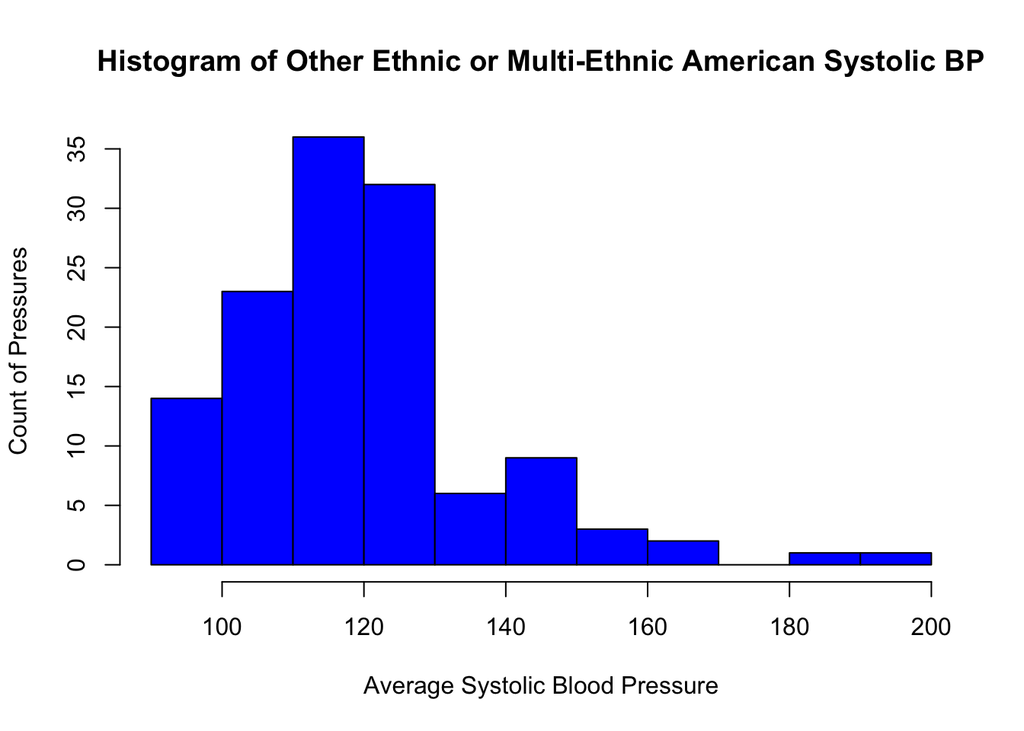

```r
# Develop a dummy dataframe for Other American histograms
dumOther <- subset(dataSubset, RIDRETH1 == 'Other Race - Including Multi-Racial')
hist_OthSyst <- hist(dumOther$SystolAvg,
                     main="Histogram of Other Ethnic or Multi-Ethnic American Systolic BP",
                     xlab="Average Systolic Blood Pressure",
                     ylab='Count of Pressures',
                     col='blue')
```

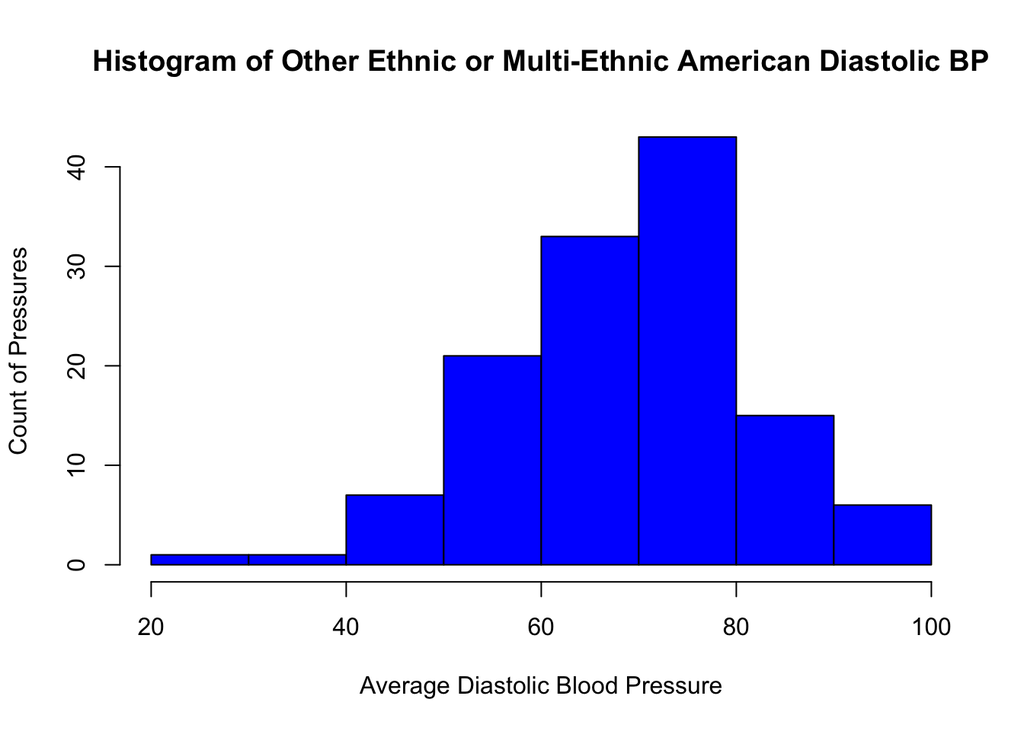

```r
hist_OthDias <- hist(dumOther$DiastolAvg,
                     main="Histogram of Other Ethnic or Multi-Ethnic American Diastolic BP",
                     xlab="Average Diastolic Blood Pressure",
                     ylab='Count of Pressures',
                     col='blue')
```

The Shapiro-Wilk Normality Test probablity values for each ethnicity’s systolic and diastolic pressure distributions are given below:

For Mexican Americans:

The Systolic Pressure Probabality Value: 1.06810^{-21}

The Diastolic Pressure Probabality Value: 8.11710^{-5}

For Other Hispanic Americans:

The Systolic Pressure Probabality Value: 2.93210^{-8}

The Diastolic Pressure Probabality Value: 0.009

For Caucasian Americans:

The Systolic Pressure Probabality Value: 3.06910^{-26}

The Diastolic Pressure Probabality Value: 1.60510^{-13}

For African Americans:

The Systolic Pressure Probabality Value: 3.18810^{-21}

The Diastolic Pressure Probabality Value: 3.01910^{-7}

For Other Ethnic or Multi-Ethnic Americans:

The Systolic Pressure Probabality Value: 3.34110^{-6}

The Diastolic Pressure Probabality Value: 0.509

Based on the shape of the histograms (which are generally more positively skewed and narrow than a normal distribution curve for the systolic and diastolic pressure distributions, respectively) and the Shapiro-Wilk Test probability values from each, only the diastolic pressures from other ethnic or multi-ethnic participants should be considered normally-distributed.

The Bartlett Probability Test results and a plot of the residuals error values from the average **systolic** blood pressures are presented below:

```r
bartlett.test(SystolAvg ~ RIDRETH1, data=dataSubset)
```

```
##
##  Bartlett test of homogeneity of variances
##
## data:  SystolAvg by RIDRETH1
## Bartlett's K-squared = 26, df = 4, p-value = 3e-05
```

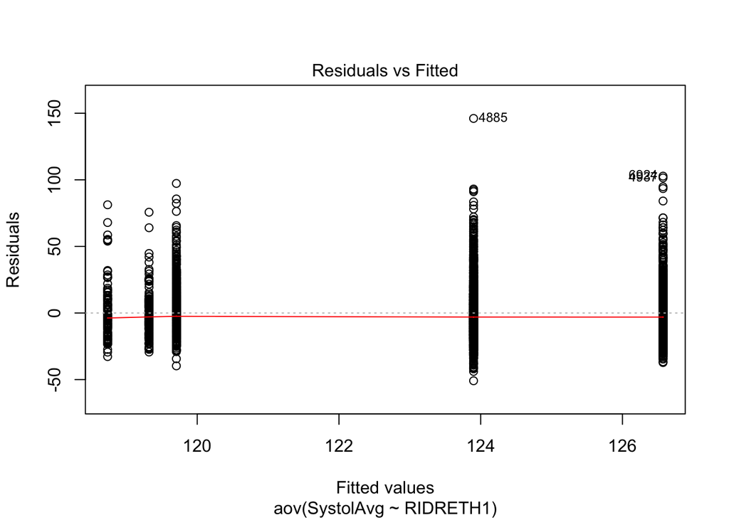

```r
# Plot the residuals from the ANOVA object to judge the idependence of the error
aov_EthSystol = aov(SystolAvg ~ RIDRETH1, data = dataSubset)
plot(aov_EthSystol, 1)
```

The Bartlett Probability Test results and a plot of the residuals error values from the average **diastolic** blood pressures are presented below:

```r
bartlett.test(DiastolAvg ~ RIDRETH1, data=dataSubset)
```

```
##
##  Bartlett test of homogeneity of variances
##
## data:  DiastolAvg by RIDRETH1
## Bartlett's K-squared = 16, df = 4, p-value = 0.003
```

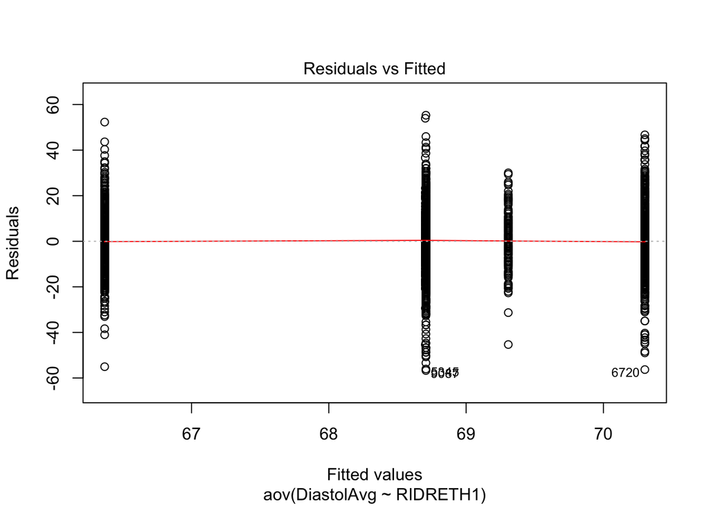

```r
# Plot the residuals from the ANOVA object to judge the idependence of the error
aov_EthDiastol = aov(DiastolAvg ~ RIDRETH1, data = dataSubset)
plot(aov_EthDiastol, 1)
```

Based on the results of the normality, Bartlett, and residuals tests, the ANOVA test results may normally be suspect; however, with a minimum sample size in the non-Mexican Hispanic ethnicity of 111, the study sample size is large enough to pull stastically-significant data.

## Do Ethnic Groups Have the Same Systolic and Diastolic Blood Pressures?

### Systolic Pressure

The results of the normality testing of the systolic blood pressure from various ethnic groups are presented with respect to each other on a single box plot below:

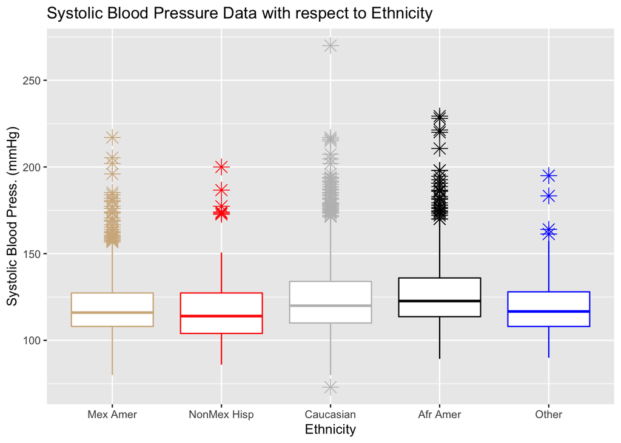

```r
# Plot Systol Averages on BoxPlot to visually commpare mean and variance data with respect to Ethnic Background
ggplot(dataSubset, aes(x=RIDRETH1, y=SystolAvg)) +
  geom_boxplot(colour=c('tan', 'red', 'grey', 'black', 'blue'), outlier.shape=8, outlier.size=4) +
  labs(title="Systolic Blood Pressure Data with respect to Ethnicity",
       x="Ethnicity", y = "Systolic Blood Press. (mmHg)") +
  # Add scale_x funciton to change label names to shorten them
  scale_x_discrete(labels = c('Mex Amer', 'NonMex Hisp', 'Caucasian', 'Afr Amer', 'Other'))
```

```r
# Dispaly the ANOVA test of the AVG Systol data against Ethnicity since we already calculated the ANOVA test results with the residuals plots
summary(aov_EthSystol)
```

```
##               Df  Sum Sq Mean Sq F value  Pr(>F)
## RIDRETH1       4   23592    5898    15.5 1.4e-12 ***
## Residuals   3452 1311767     380
## ---
## Signif. codes:  0 '***' 0.001 '**' 0.01 '*' 0.05 '.' 0.1 ' ' 1
```

Based on the results of the box plot, which shows a small but noticable difference in the mean systolic blood pressures as high as ~10 mmHg, and the ANOVA test with an ANOVA probablity value significantly less than 0.05, the systolic blood pressures between the ethnic groups are *not* equivalent.

The results of the Scheffe Multiple Comparisons test are reported below:

```r
# Run the Scheffe Test to see with Ethnicities can be considered to have the same Systolic Blood Pressures
eth_SystCompar <- scheffe.test(aov_EthSystol,"RIDRETH1", group=TRUE, console=TRUE,
   main="Systolic Blood Pressure between Different Ethnicities")
```

```
##
## Study: Systolic Blood Pressure between Different Ethnicities
##
## Scheffe Test for SystolAvg
##
## Mean Square Error  : 380
##
## RIDRETH1,  means
##
##                                     SystolAvg  std    r  Min Max
## Mexican American                          120 17.4  764 80.0 217
## Non-Hispanic Black                        127 19.9  823 89.3 229
## Non-Hispanic White                        124 20.3 1632 73.0 270
## Other Hispanic                            119 20.4  111 86.0 200
## Other Race - Including Multi-Racial       119 17.8  127 90.0 195
##
## Alpha: 0.05 ; DF Error: 3452
## Critical Value of F: 2.37
##
## Groups according to probability of means differences and alpha level( 0.05 )
##
## Means with the same letter are not significantly different.
##
##                                     SystolAvg groups
## Non-Hispanic Black                        127      a
## Non-Hispanic White                        124      b
## Mexican American                          120      c
## Other Race - Including Multi-Racial       119      c
## Other Hispanic                            119      c
```

From the Scheffe results, Caucasian, African, and all Hispanic and other ethnicities have different systolic blood pressures. Mexican, other Hispanic, and all other or multi-ethnic Americans from the survey are considered to have the same systolic blood pressure which is different and lower than Caucasian American systolic blood pressure which, in turn, is different and lower than African American systolic blood pressure.